# Replication of Figure G–H: Enhancer and Promoter Distribution of YAP/TAZ/TEAD4 Peaks

Harshini Muthukumar

2026-03-19

### Figure 1g

Figure 1g is an IGV track view. I have already generated the bigwig files andloaded them to IGV and took a screenshot.

Below is one of the known YAP1 target gene CCN2:

### IGV View

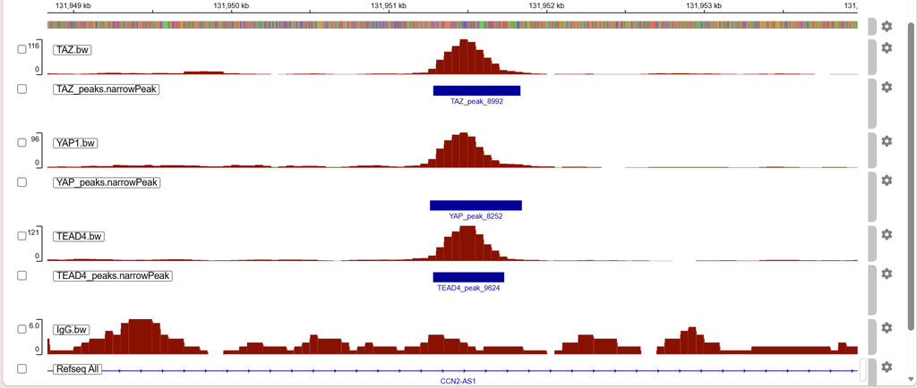

### Figure 1h

Figure 1h is a pie chart showing the proportion of the annotation of the YAP/TAZ/TEAD4 common peaks. The annotations are: promoters, active enhancers, inactive enhancers and not classified.

promoters are YAP/TAZ/TEAD4 peaks overlapping with H3K4me3 peaks active enhancers are YAP/TAZ/TEAD4 peaks overlapping with H3K4me1 and H3K27ac peaks inactive enhancers are YAP/TAZ/TEAD4 peaks overlapping with H3K4me1 but not H3K37ac peaks

```r
H3K4me1<- import(here("C:/Users/harzi/OneDrive/Desktop/chip_seq_peak/H3K4me1.bed"))
H3K4me3<- import(here("C:/Users/harzi/OneDrive/Desktop/chip_seq_peak/H3K4me3.bed"))
H3K27ac<- import(here("C:/Users/harzi/OneDrive/Desktop/chip_seq_peak/H3K27ac.bed"))
```

The presence of H3K4me1 and H3K4me3 peaks, their genomic locations and their overlap were the criteria used to define promoters and enhancers: **i) H3K4me3 peaks not overlapping with H3K4me1 peaks and close to a TSS (± 5kb) were defined as promoters, as NA otherwise; ii) H3K4me1 peaks not overlapping with H3K4me3 peaks were defined as enhancers; iii) regions with the co-presence of H3K4me1 and H3K4me3 peaks were visually inspected on IGV and were defined as promoters, enhancers or NA after the evaluation of the proximity to a TSS and the comparison of the enrichment signals**. Finally, promoters or enhancers were defined as active if overlapping with H3K27ac peaks.

YAP/TAZ/TEAD peaks annotation YAP/TAZ/TEAD peaks were annotated as promoters or enhancers if their summit was overlapping with promoter or enhancer regions as defined above. Peaks with the summit falling in regions with no H3K4me1 or H3K4me3 peaks, or in NA regions were defined as “not assigned” and discarded from subsequent analyses.

```r
annotation_df<- data.frame(category = c("active_enhancers", "inactive_enhancers",
                        "promoters", "unclassified"),
peak_number = c(n_active_enhancers, n_inactive_enhancers,
                n_promoters, n_unclassified))


annotation_df
```

```
##             category peak_number
## 1   active_enhancers        3972
## 2 inactive_enhancers         118
## 3          promoters         274
## 4       unclassified        1601
```

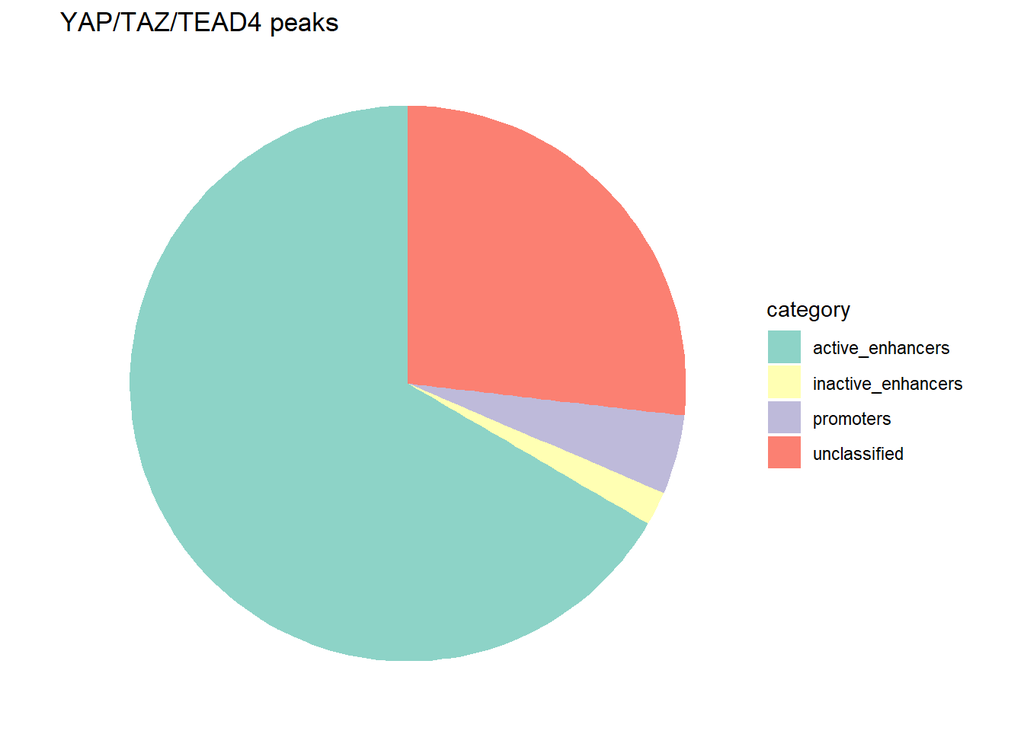

```r
ggplot(annotation_df, aes(x = "", y = peak_number, fill = category)) +
  geom_bar(stat = "identity", width = 1) +
  coord_polar("y", start = 0) +
  theme_void() + # Remove unnecessary axes
  labs(title = "YAP/TAZ/TEAD4 peaks") +
  scale_fill_brewer(palette = "Set3")
```

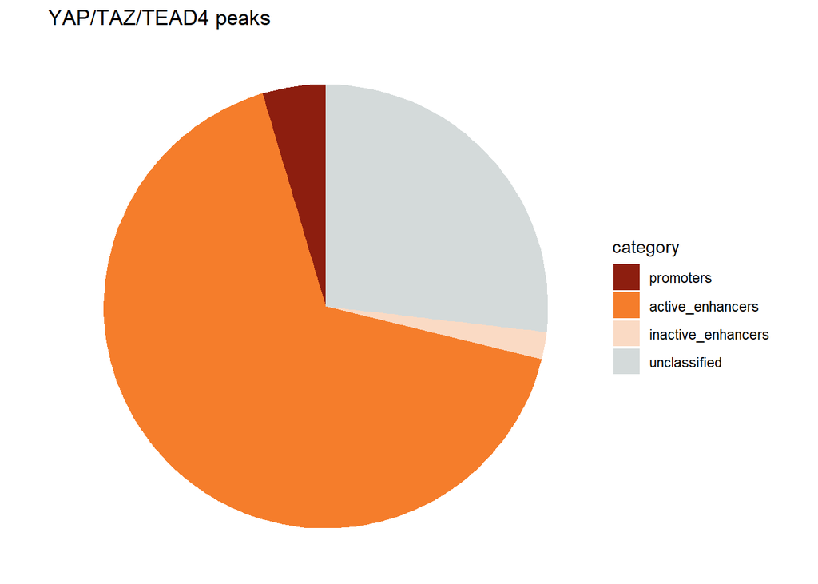

[output not shown]

[figure not shown]

```r
annotation_df$category<- factor(annotation_df$category,
                                levels = c("promoters", "active_enhancers",
                                           "inactive_enhancers", "unclassified"))

colors<- c("#8D1E0F", "#F57D2B", "#FADAC4", "#D4DADA")

ggplot(annotation_df, aes(x = "", y = peak_number, fill = category)) +
  geom_bar(stat = "identity", width = 1) +
  coord_polar("y", start = 0) +
  theme_void() + # Remove unnecessary axes
  labs(title = "YAP/TAZ/TEAD4 peaks") +
  scale_fill_manual(values = colors)
```

This pie chart illustrates the genomic distribution of YAP/TAZ/TEAD4 binding peaks across four regulatory element categories. The data reveals that the vast majority of YAP/TAZ/TEAD4 occupancy occurs at active enhancers (66.6%), suggesting that these transcriptional co-activators predominantly function by targeting distal regulatory elements in an active chromatin state, rather than directly binding gene promoters. A substantial fraction of peaks (26.8%) remain unclassified, potentially representing novel or unannotated regulatory regions. A smaller but notable proportion maps to promoters (4.6%), indicating some degree of direct promoter engagement. Strikingly, only 2% of peaks overlap with inactive enhancers, implying that YAP/TAZ/TEAD4 binding is strongly associated with transcriptionally permissive chromatin.